# Machine Learning Project (DS8)

Classification through random forest prediction

Jeremy Stalberger

November 5, 2017

## Executive Summary

In this project we sought to develop a predictive model for classifying the manner in which an exercise was performed based on activity measurements. The dataset used to train the model contains accelerometer data and the corresponding activity performed by 6 participants. Specifically, a barbell lift was performed by each participant in a correct manner as well as 4 incorrect manners and a variety of accelerometer readings captured from the belt, forearm, arm, and dumbell during the exercise. After processing the data, a random forest method with 10-fold cross validation was applied to develop the predictive model. This model was then applied to a test dataset to predict the classe variable of 20 different test cases.

## Data Processing

### Install and Load Libraries

Any necessary R packages are installed and loaded.

```r
# Install Necessary Packages
requiredPackages <- c("caret", "plyr", "randomForest", "ggplot2")
ipak <- function(pkg)
    {
    new.pkg <- pkg[!(pkg %in% installed.packages()[, "Package"])]
    if (length(new.pkg))
        install.packages(new.pkg, dependencies = TRUE)
    sapply(pkg, require, character.only = TRUE)
    }
ipak(requiredPackages)
```

```
##        caret         plyr randomForest      ggplot2
##         TRUE         TRUE         TRUE         TRUE
```

```r
# Invoke libraries
library(caret)
library(plyr)
library(randomForest)
library(ggplot2)
```

### Download and Load Raw Data

The raw data files are loaded from the following links:

pml-training.csv

pml-testing.csv

```r
# Download the source files
fileurl1 ="https://d396qusza40orc.cloudfront.net/predmachlearn/pml-training.csv"
fileurl2 ="https://d396qusza40orc.cloudfront.net/predmachlearn/pml-testing.csv"
filename1="pml-training.csv"
filename2="pml-testing.csv"
if(!file.exists(filename1)){download.file(fileurl1,filename1)}
if(!file.exists(filename2)){download.file(fileurl2,filename2)}
# Read the data files
training <- read.csv("pml-training.csv",header=TRUE)
testing  <- read.csv("pml-testing.csv", header=TRUE)
```

### Explore Raw Data

It’s important to explore the dataset before analysis. A brief sample of that exploration can be found below.

```r
# Examine data
dim(training)
```

```
## [1] 19622   160
```

```r
summary(training$classe)
```

```
##    A    B    C    D    E
## 5580 3797 3422 3216 3607
```

```r
training[1:3,1:10]
```

```
##   X user_name raw_timestamp_part_1 raw_timestamp_part_2   cvtd_timestamp
## 1 1  carlitos           1323084231               788290 05/12/2011 11:23
## 2 2  carlitos           1323084231               808298 05/12/2011 11:23
## 3 3  carlitos           1323084231               820366 05/12/2011 11:23
##   new_window num_window roll_belt pitch_belt yaw_belt
## 1         no         11      1.41       8.07    -94.4
## 2         no         11      1.41       8.07    -94.4
## 3         no         11      1.42       8.07    -94.4
```

```r
sum(is.na(training$classe)) # Check for NA values
```

```
## [1] 0
```

### Subset and Organize Data

Unnecessary variables are removed, included those that contain mostly NA values.

```r
training.raw <- training                 # Retain raw dataset
testing.raw  <- testing                  # Retain raw dataset
training[training==""] <- NA             # Replace Empty Values "" with "NA"
testing [testing ==""] <- NA             # Replace Empty Values "" with "NA"
Keep <- (colSums(is.na(training)) == 0)  # Identify columns without NA values
training <- training[, Keep]             # Eliminate columns with NA values
testing  <- testing [, Keep]             # Eliminate columns with NA values
training <- training[-c(1,3,4,5,6)]      # Remove unnecessary columns
dim(training)
```

```
## [1] 19622    55
```

```r
training[1:2,1:4]
```

```
##   user_name num_window roll_belt pitch_belt
## 1  carlitos         11      1.41       8.07
## 2  carlitos         11      1.41       8.07
```

## Analysis

### Variable Selection

The variable we are interested in predicting in our model is the “classe” variable. The remaining accelerometer data will be used for prediction. In addition to the accelerometer data, the participant variable (user_name) and num_window variable are both worthy of consideration for our model.

To evaluate the two additional variables for inclusion and better understand their influence in the dataset, a principle component analysis was performed. As shown in the appendix, the resulting scatterplots of PC1 and PC2 colored by these variables illustrate their role relative to the classe variable. It is interesting to note the distinct groupings by user_name, which confirms the idea that the accelerometer data exhibits a unique “fingerprint” for each of the participants (with some exceptions, particularly the overlap between Carlitos and Eurico). The num_window variable captures this grouping behavior as well. It does so to a higher degree of granularity since it is a subset of both user_name and classe. We can see that this higher granularity appears to capture some useful information when we compare it to the scatterplot by classe. Although training our model to this level of granularity could have downsides if our test data contained new participants with non-overlapping characteristics, we know from looking at the test data that this is not the case. As a result, we proceed forward with including num_window and choose to remove user_name from the training data.

```r
training <- training[-c(1)] # Remove user_name (Col 1) & Keep num_window (Col 2)
```

### Random Forest Model

To speed up the random forest model calculation, we’ll take a subset of the training data. The remaining data will go into the validation dataset. Although it’s not necessary given the 10-fold cross-validation that will be used, we’ll utilize the validation dataset to calculate our out of sample error.

```r
# Partition training data
set.seed(1234)
InTrain    <- createDataPartition(y=training$classe,p=0.5,list=FALSE)
training2  <- training[InTrain,]
validation <- training[-InTrain,]
```

Now we create our predictive model. A random forest model was chosen due to the characteristic noise in the sensor data. Let’s apply a 10-fold cross validation random forest method to the training dataset.

```r
# Create Random Forest Model
set.seed(2345)
mod.RF  <- train(classe~.,data=training2,method="rf",prox=TRUE,allowParallel=TRUE,
                 trControl=trainControl(method="cv",number=10))
```

### Model Results

Below we review the results, including the fitted model, out of sample error rate, and resulting prediction on the test dataset.

```r
print(mod.RF)
```

```
## Random Forest
##
## 9812 samples
##   53 predictor
##    5 classes: 'A', 'B', 'C', 'D', 'E'
##
## No pre-processing
## Resampling: Cross-Validated (10 fold)
## Summary of sample sizes: 8831, 8831, 8831, 8832, 8830, 8832, ...
## Resampling results across tuning parameters:
##
##   mtry  Accuracy   Kappa
##    2    0.9906245  0.9881394
##   27    0.9944969  0.9930382
##   53    0.9905214  0.9880089
##
## Accuracy was used to select the optimal model using  the largest value.
## The final value used for the model was mtry = 27.
```

```r
print(mod.RF$finalModel)
```

```
##
## Call:
##  randomForest(x = x, y = y, mtry = param$mtry, proximity = TRUE,      allowParallel = TRUE)
##                Type of random forest: classification
##                      Number of trees: 500
## No. of variables tried at each split: 27
##
##         OOB estimate of  error rate: 0.46%
## Confusion matrix:
##      A    B    C    D    E  class.error
## A 2789    0    0    0    1 0.0003584229
## B   11 1887    1    0    0 0.0063191153
## C    0   12 1699    0    0 0.0070134424
## D    0    0   12 1596    0 0.0074626866
## E    0    1    1    6 1796 0.0044345898
```

```r
confusionMatrix(validation$classe,predict(mod.RF,validation))
```

```
## Confusion Matrix and Statistics
##
##           Reference
## Prediction    A    B    C    D    E
##          A 2790    0    0    0    0
##          B    6 1885    3    4    0
##          C    0    5 1706    0    0
##          D    0    0   14 1594    0
##          E    0    0    0    6 1797
##
## Overall Statistics
##
##                Accuracy : 0.9961
##                  95% CI : (0.9947, 0.9973)
##     No Information Rate : 0.285
##     P-Value [Acc > NIR] : < 2.2e-16
##
##                   Kappa : 0.9951
##  Mcnemar's Test P-Value : NA
##
## Statistics by Class:
##
##                      Class: A Class: B Class: C Class: D Class: E
## Sensitivity            0.9979   0.9974   0.9901   0.9938   1.0000
## Specificity            1.0000   0.9984   0.9994   0.9983   0.9993
## Pos Pred Value         1.0000   0.9932   0.9971   0.9913   0.9967
## Neg Pred Value         0.9991   0.9994   0.9979   0.9988   1.0000
## Prevalence             0.2850   0.1927   0.1756   0.1635   0.1832
## Detection Rate         0.2844   0.1922   0.1739   0.1625   0.1832
## Detection Prevalence   0.2844   0.1935   0.1744   0.1639   0.1838
## Balanced Accuracy      0.9989   0.9979   0.9948   0.9960   0.9996
```

```r
pred.RF <- predict(mod.RF, newdata=testing)
print(pred.RF)
```

```
##  [1] B A B A A E D B A A B C B A E E A B B B
## Levels: A B C D E
```

As we can see above, the accuracy of the model is impressive, with an estimated error rate of 0.39% as calculated by the validation dataset.

## Conclusion

The analysis above sought to fit a predictive model to the accelerometer data in order to predict the classe variable. Using a random forest model resulted in a highly accurate classe prediction of 99.61%. This result gives us high confidence in the accuracy of the 20 predicted test cases.

## Appendix

### Principle Component Analysis and PCA Scatterplot by Participant

```r
training3 <- training.raw
training3[training3==""] <- NA
training3 <- training3[, Keep]
training3$num_window <- as.factor(training3$num_window)
training3 <- training3[-c(1,3,4,5,6)]

# InTrain2   <- createDataPartition(y=training3$classe,p=0.5,list=FALSE)  # Subset if necessary
# training3  <- training3[InTrain2,]                                      # Subset if necessary

preProc <- preProcess(training3,method="pca",thresh=0.8)
trainPC <- predict(preProc,training3)
names(trainPC)
```

```
##  [1] "user_name"  "num_window" "classe"     "PC1"        "PC2"
##  [6] "PC3"        "PC4"        "PC5"        "PC6"        "PC7"
## [11] "PC8"        "PC9"        "PC10"       "PC11"       "PC12"
```

```r
p <- ggplot(trainPC, aes(x=PC1, y=PC2, color=user_name)) +
    geom_point() + theme_bw() +
    labs(title=expression("Principle Component Analysis Scatterplot by Participant"))
    theme(legend.position="right")
```

```
## List of 1
##  $ legend.position: chr "right"
##  - attr(*, "class")= chr [1:2] "theme" "gg"
##  - attr(*, "complete")= logi FALSE
##  - attr(*, "validate")= logi TRUE
```

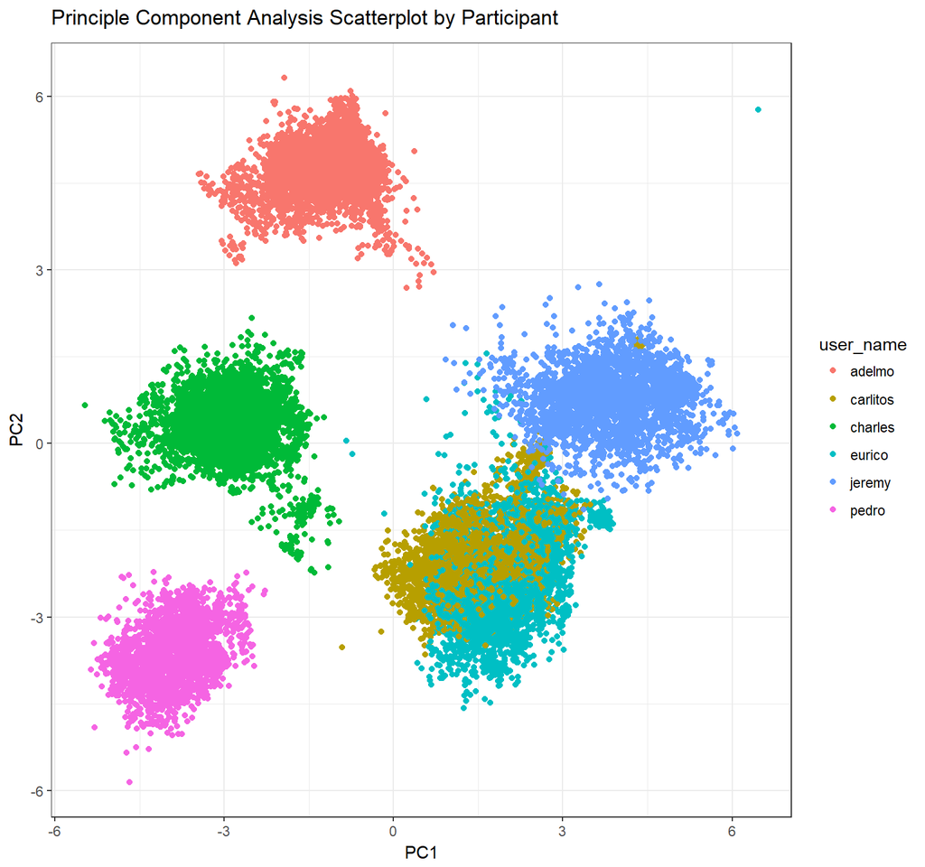

```r
print(p)
```

### Principle Component Analysis Scatterplot by num_window

```r
p <- ggplot(trainPC, aes(x=PC1, y=PC2, color=num_window)) +
    geom_point(show.legend=F) + theme_bw() +
    labs(title=expression("Principle Component Analysis Scatterplot by num_window"))
    theme(legend.position="right")
```

```
## List of 1
##  $ legend.position: chr "right"
##  - attr(*, "class")= chr [1:2] "theme" "gg"
##  - attr(*, "complete")= logi FALSE
##  - attr(*, "validate")= logi TRUE
```

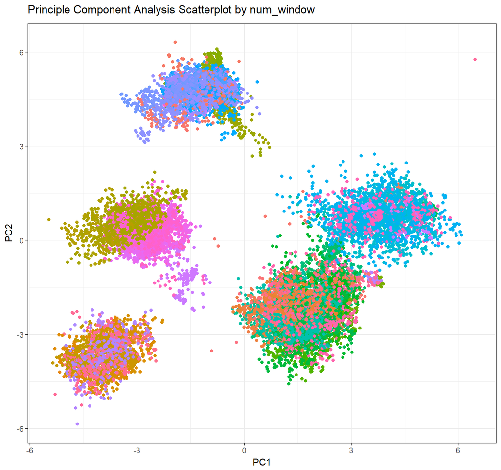

```r
print(p)
```

### Principle Component Analysis Scatterplot by classe

```r
p <- ggplot(trainPC, aes(x=PC1, y=PC2, color=classe)) +
    geom_point() + theme_bw() +
    labs(title=expression("Principle Component Analysis Scatterplot by classe"))
    theme(legend.position="right")
```

```
## List of 1
##  $ legend.position: chr "right"
##  - attr(*, "class")= chr [1:2] "theme" "gg"
##  - attr(*, "complete")= logi FALSE
##  - attr(*, "validate")= logi TRUE
```

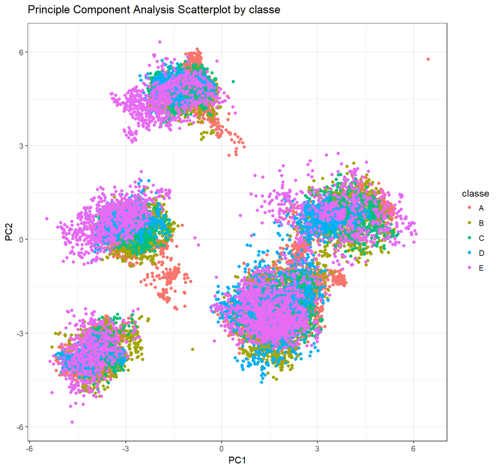

```r
print(p)
```